# KL

```r
library(readr)
library(ggplot2)
library(dplyr)
library(scales)
library(tidyr)
library(tibble)
library(plotly)
library(patchwork)
library(broom)
```

```r
D <- readRDS("D_matrix.rds")
D_ori <- D
```

```r
class(D)
```

```
## [1] "data.frame"
```

```r
dim(D)
```

```
## [1] 184152   1481
```

```r
D[1:3, 1:3]
```

```
##                  LID_1066617_PID_10504 LID_1066618_PID_10504
## chr1_22510_22551                0.3125          0.1730769231
## chr1_70381_70381                     .                     .
## chr1_84369_84369                     .                     .
##                  LID_1066619_PID_10504
## chr1_22510_22551          0.1612903226
## chr1_70381_70381                     .
## chr1_84369_84369                     .
```

```r
D[D == "."] <- NA
D <- as.data.frame(lapply(D, as.numeric))
```

```r
keep <- rowMeans(!is.na(D)) >= 0.75
D_filt <- D[keep, ]
dim(D_filt)
```

```
## [1] 138538   1481
```

```r
global_means <- data.frame(
  lid_pid = colnames(D_filt),
  mean_discordance = colMeans(D_filt, na.rm = TRUE)
)
head(global_means)
```

```
##                                     lid_pid mean_discordance
## LID_1066617_PID_10504 LID_1066617_PID_10504        0.1834158
## LID_1066618_PID_10504 LID_1066618_PID_10504        0.1948982
## LID_1066619_PID_10504 LID_1066619_PID_10504        0.1974455
## LID_1066620_PID_10504 LID_1066620_PID_10504        0.1981625
## LID_1066621_PID_10504 LID_1066621_PID_10504        0.1811795
## LID_1066622_PID_10504 LID_1066622_PID_10504        0.1895881
```

```r
meta <- readRDS("dap_rrbs-metaData.rds")
```

```r
df <- merge(global_means, meta, by = "lid_pid")

# rename mean column so it can't collide with base::mean()
names(df)[names(df) == "mean"] <- "mean_discordance"

df$age_c <- as.numeric(scale(df$Age_at_sample, center = TRUE, scale = FALSE))
df$predicted_height_c <- as.numeric(scale(df$predicted_height, center = TRUE, scale = FALSE))
```

```r
df$age_c <- as.numeric(scale(df$Age_at_sample, center = TRUE, scale = FALSE))
df$predicted_height_c <- as.numeric(scale(df$predicted_height, center = TRUE, scale = FALSE))

fit_lm <- lm(
  mean_discordance ~ age_c*predicted_height_c + Sex_bool + Fixed_bool + log(reads) + Perc_unique,
  data = df
)
summary(fit_lm)
```

```
##
## Call:
## lm(formula = mean_discordance ~ age_c * predicted_height_c +
##     Sex_bool + Fixed_bool + log(reads) + Perc_unique, data = df)
##
## Residuals:
##       Min        1Q    Median        3Q       Max
## -0.040925 -0.009356 -0.002025  0.008355  0.066266
##
## Coefficients:
##                            Estimate Std. Error t value Pr(>|t|)
## (Intercept)               0.2087068  0.0114211  18.274  < 2e-16 ***
## age_c                     0.0006461  0.0001219   5.299 1.34e-07 ***
## predicted_height_c       -0.0009737  0.0006586  -1.478 0.139498
## Sex_bool                  0.0018375  0.0007192   2.555 0.010727 *
## Fixed_bool                0.0003554  0.0009982   0.356 0.721876
## log(reads)               -0.0001219  0.0006284  -0.194 0.846276
## Perc_unique              -0.0198517  0.0053218  -3.730 0.000199 ***
## age_c:predicted_height_c  0.0005086  0.0002053   2.478 0.013335 *
## ---
## Signif. codes:  0 '***' 0.001 '**' 0.01 '*' 0.05 '.' 0.1 ' ' 1
##
## Residual standard error: 0.01367 on 1473 degrees of freedom
## Multiple R-squared:  0.04293,    Adjusted R-squared:  0.03838
## F-statistic:  9.44 on 7 and 1473 DF,  p-value: 1.691e-11
```

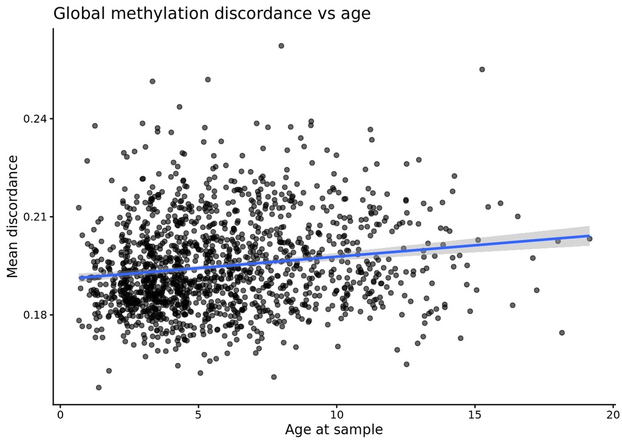

```r
ggplot(df, aes(x = Age_at_sample, y = mean_discordance)) +
  geom_point(alpha = 0.6) +
  geom_smooth(method = "lm", se = TRUE) +
  labs(
    x = "Age at sample",
    y = "Mean discordance",
    title = "Global methylation discordance vs age"
  ) +
  theme_classic()
```

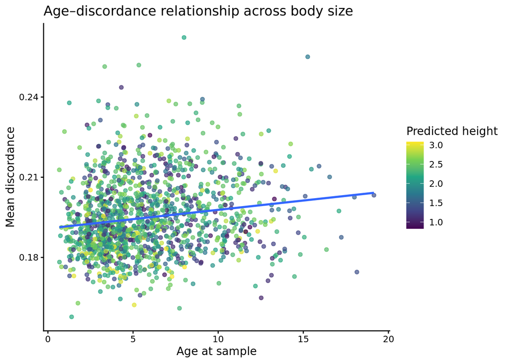

```r
ggplot(df, aes(x = Age_at_sample, y = mean_discordance,
               color = predicted_height)) +
  geom_point(alpha = 0.7) +
  geom_smooth(method = "lm", se = FALSE) +
  scale_color_viridis_c() +
  labs(
    x = "Age at sample",
    y = "Mean discordance",
    color = "Predicted height",
    title = "Age–discordance relationship across body size"
  ) +
  theme_classic()
```

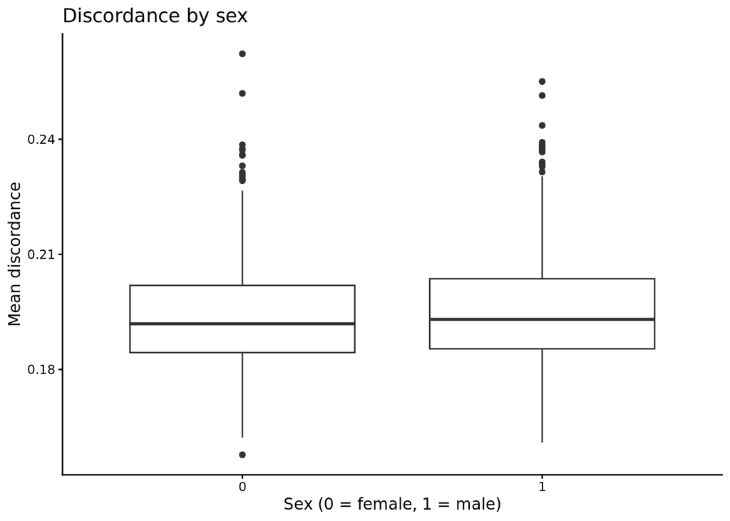

```r
ggplot(df, aes(x = factor(Sex_bool), y = mean_discordance)) +
  geom_boxplot() +
  labs(
    x = "Sex (0 = female, 1 = male)",
    y = "Mean discordance",
    title = "Discordance by sex"
  ) +
  theme_classic()
```

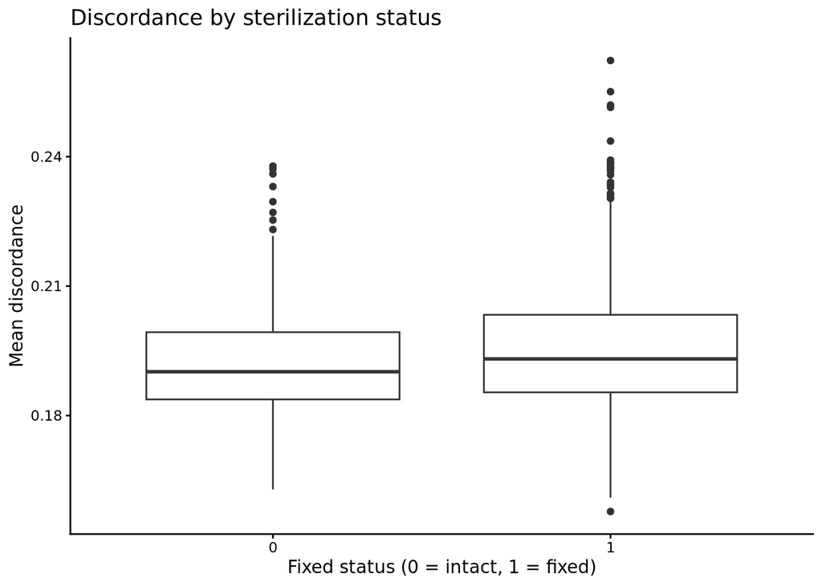

```r
ggplot(df, aes(x = factor(Fixed_bool), y = mean_discordance)) +
  geom_boxplot() +
  labs(
    x = "Fixed status (0 = intact, 1 = fixed)",
    y = "Mean discordance",
    title = "Discordance by sterilization status"
  ) +
  theme_classic()
```

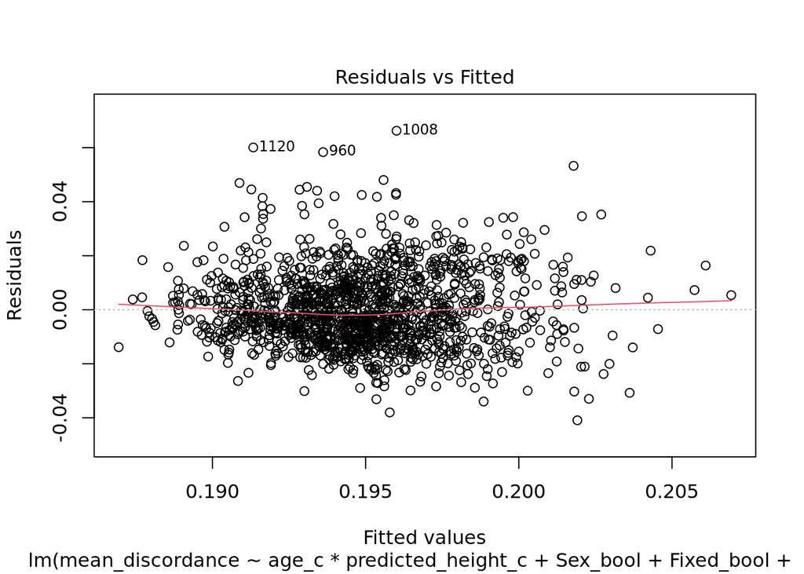

```r
par(mfrow = c(1, 1))  # reset layout

plot(fit_lm, which = 1)  # Residuals vs Fitted
```

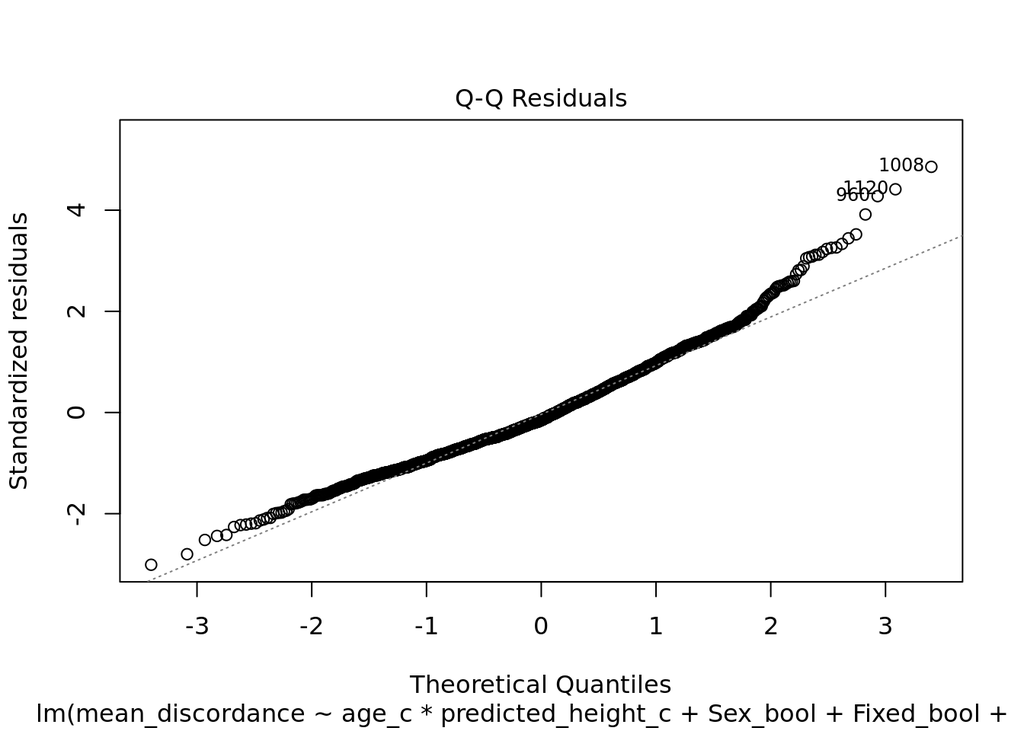

```r
plot(fit_lm, which = 2)  # Q-Q plot
```

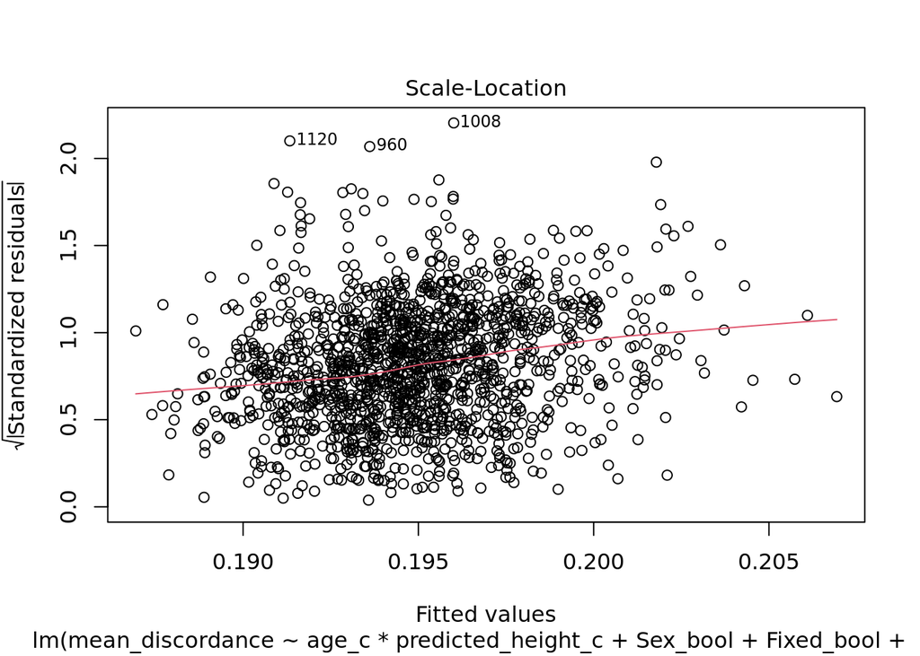

```r
plot(fit_lm, which = 3)  # Scale-Location
```

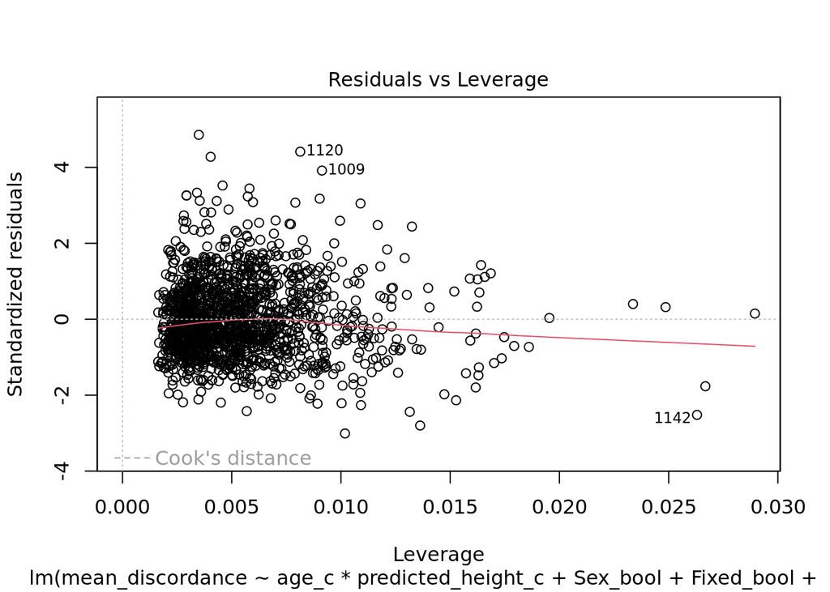

```r
plot(fit_lm, which = 5)  # Residuals vs Leverage
```

### From this is my work

```r
row_and_col <- data.frame(
  row = nrow(D),
  col = ncol(D)
)
row_and_col
```

```
##      row  col
## 1 184152 1481
```

So *Row* > *Col* so the genome_driven analysis

```r
temp <- D
```

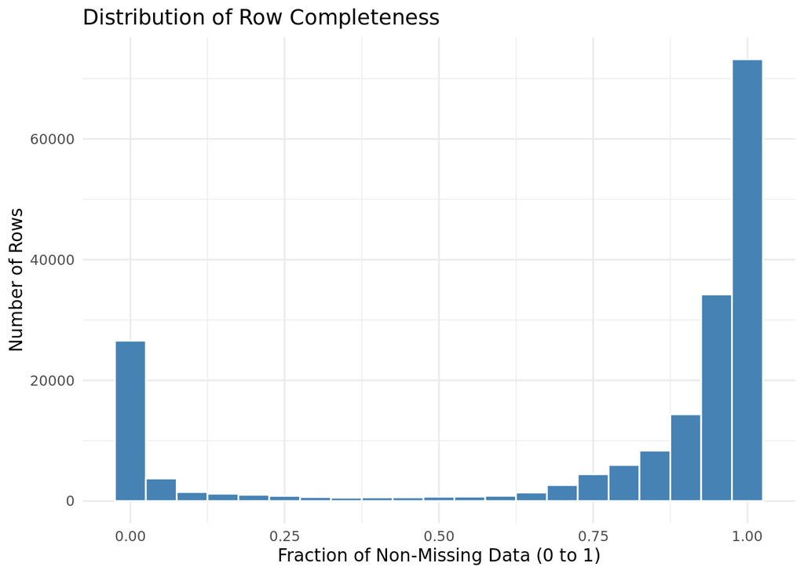

```r
# 1. Create the summary table
row_completeness <- temp %>%
  # Calculate the fraction of non-NA values for each row
  mutate(
    non_na_fraction = rowMeans(!is.na(.)),
    na_fraction = 1 - non_na_fraction
  ) %>%
  # Keep only the calculation results
  select(non_na_fraction, na_fraction)

# 2. Create the histogram
ggplot(row_completeness, aes(x = non_na_fraction)) +
  geom_histogram(binwidth = 0.05, fill = "steelblue", color = "white") +
  labs(
    title = "Distribution of Row Completeness",
    x = "Fraction of Non-Missing Data (0 to 1)",
    y = "Number of Rows"
  ) +
  theme_minimal()
```

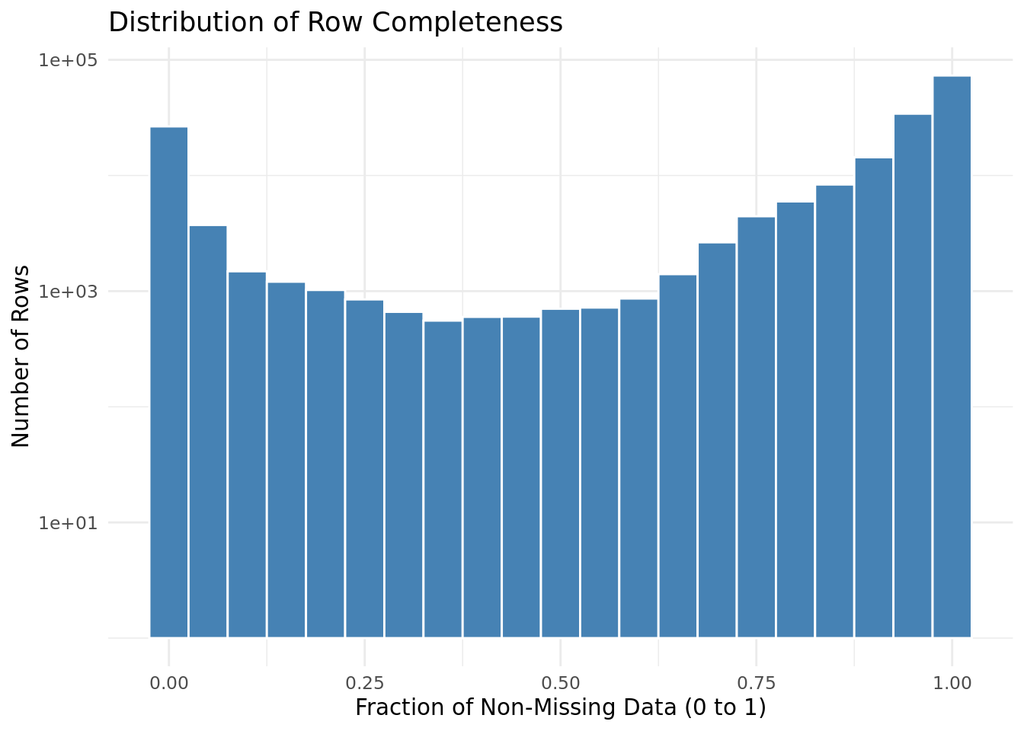

```r
# 2. Create the histogram
ggplot(row_completeness, aes(x = non_na_fraction)) +
  geom_histogram(binwidth = 0.05, fill = "steelblue", color = "white") +
  scale_y_log10() +
  labs(
    title = "Distribution of Row Completeness",
    x = "Fraction of Non-Missing Data (0 to 1)",
    y = "Number of Rows"
  ) +
  theme_minimal()
```

The fillness of the data is curve to the right; the matrix have the majority of the fillness with non N/A data is in the range 75% to 100%; so we can collect and calculate data from 75% to 100% fillness; this is why we make a 75% filter

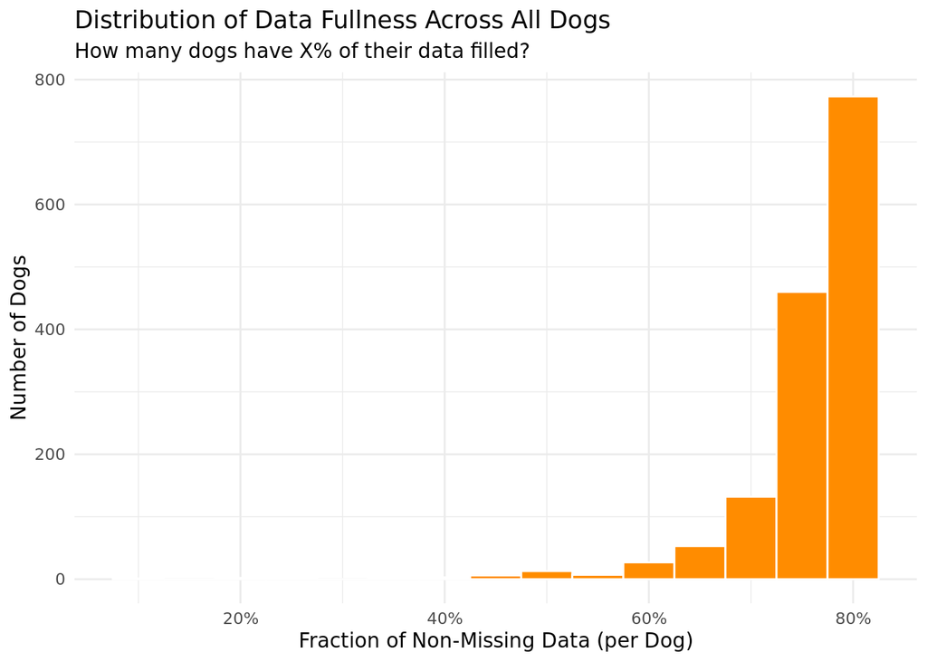

```r
# 1. Calculate the fraction of non-NA values for each column (dog)
dog_completeness <- temp %>%
  summarise(across(everything(), ~ mean(!is.na(.)))) %>%
  # Pivot so we have one row per dog
  pivot_longer(everything(), names_to = "dog_name", values_to = "fraction_filled")

# 2. Create the histogram
ggplot(dog_completeness, aes(x = fraction_filled)) +
  geom_histogram(binwidth = 0.05, fill = "darkorange", color = "white") +
  scale_x_continuous(labels = scales::percent_format()) +
  labs(
    title = "Distribution of Data Fullness Across All Dogs",
    subtitle = "How many dogs have X% of their data filled?",
    x = "Fraction of Non-Missing Data (per Dog)",
    y = "Number of Dogs"
  ) +
  theme_minimal()
```

Cool, so the main distribution of window completeness is at least 60%; so we can say the majourity of the dog have at least 60-80% genetic window filled

```r
window_df <- tibble(
  window_id = rownames(D) %||% as.character(seq_len(nrow(D))),
  n_total = ncol(D),
  n_obs = rowSums(!is.na(D)),
  prob_obs = n_obs/n_total,
  prop_na = 1 - prob_obs,
  mean_val = rowMeans(D, na.rm = TRUE),
  var_val = apply(D, 1, var, na.rm = TRUE)
) %>%
  mutate(var_val = ifelse(n_obs < 2, NA_real_, var_val))
```

this making 3 new variables: prob_obs: how often a window is showed mean_val = arverage signal of that window across dogs var-val = how much it varies across dogs

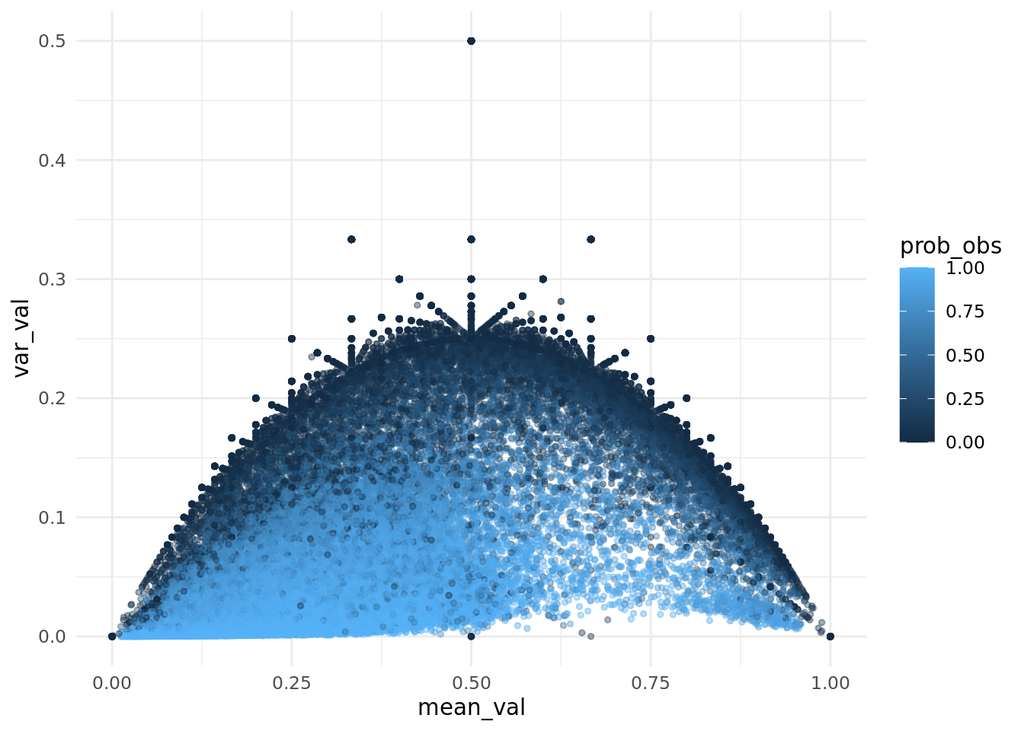

```r
ggplot(window_df, aes(mean_val, var_val, color = prob_obs)) +
  geom_point(alpha = 0.4, size = 1) +
  theme_minimal()
```

This plot is arched, saying that varinace of each dogs for each window is bounded between 0 and 1; where peak of variance is arounf 0.5 which is nice I think? but there are still dogs that have lower than 0.5 of the variance among those windows; there is no dog that have the variance highter than 1 which will make this have a higher chance of close to the true mean

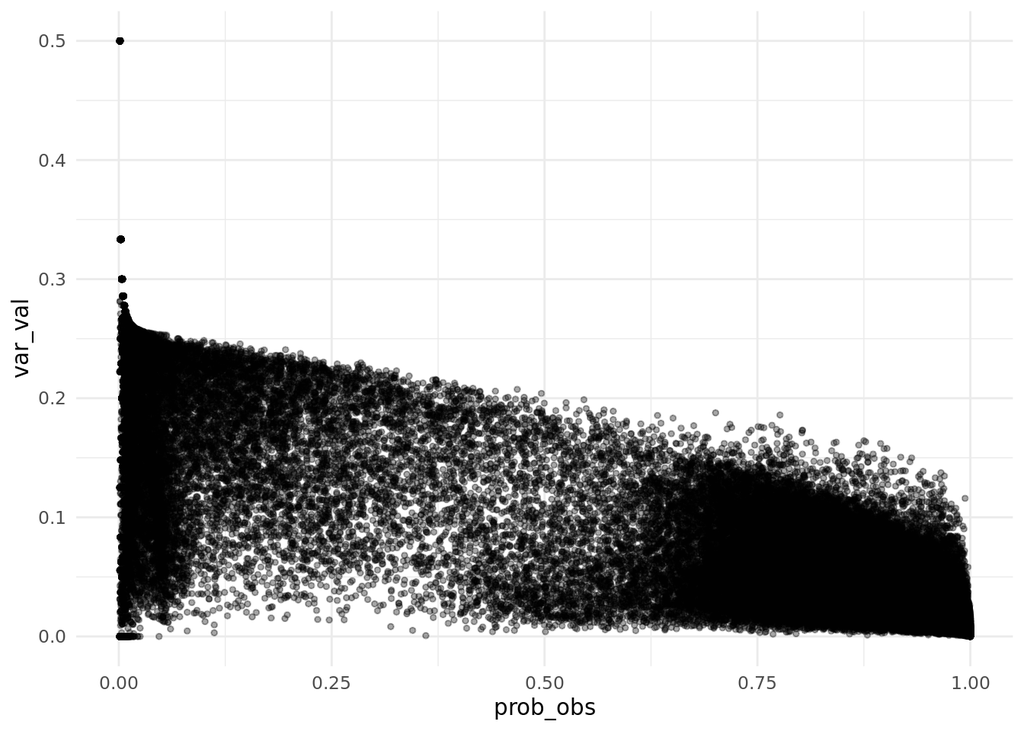

```r
ggplot(window_df, aes(prob_obs, var_val)) +
  geom_point(alpha = 0.35, size = 1) +
  theme_minimal()
```

number of a window observed to in every dog increase, which make the variance decrease; The negative relationship between observation probability and variance suggests that high-coverage windows represent epigenetically stable regions, whereas low-coverage windows display elevated heterogeneity consistent with sampling effects and locus-specific variability

```r
# D is your matrix/data.frame with windows as rows, samples as cols
# meta is your metadata data frame

colnames(D) <- trimws(as.character(colnames(D)))
meta$lid_pid <- trimws(as.character(meta$lid_pid))

# Check mismatches (should be empty or very small)
missing_in_meta <- setdiff(colnames(D), meta$lid_pid)
missing_in_D    <- setdiff(meta$lid_pid, colnames(D))

head(missing_in_meta, 20)
```

```
## character(0)
```

```r
length(missing_in_meta)
```

```
## [1] 0
```

```r
col_map <- meta %>%
  select(lid_pid, dog_id) %>%
  distinct() %>%
  filter(lid_pid %in% colnames(D))

cols_by_dog <- split(col_map$lid_pid, col_map$dog_id)

D_dog <- sapply(names(cols_by_dog), function(dog) {
  cols <- cols_by_dog[[dog]]
  rowMeans(as.matrix(D[, cols, drop = FALSE]), na.rm = TRUE)
})

D_dog <- as.matrix(D_dog)
dim(D_dog)   # windows x dogs
```

```
## [1] 184152    877
```

```r
dogs_in_D <- colnames(D_dog)
dogs_in_meta <- unique(meta$dog_id)

c(
  n_D = length(dogs_in_D),
  n_meta = length(dogs_in_meta),
  overlap = length(intersect(dogs_in_D, dogs_in_meta))
)
```

```
##     n_D  n_meta overlap
##     877     900     877
```

```r
dog_stats <- tibble(
  dog_id   = colnames(D_dog),
  mean_dis = colMeans(D_dog, na.rm = TRUE),
  var_dis  = apply(D_dog, 2, var, na.rm = TRUE),
  n_win    = colSums(!is.na(D_dog))
)

analysis_df <- dog_stats %>%
  left_join(meta %>% distinct(dog_id, .keep_all = TRUE), by = "dog_id")
```

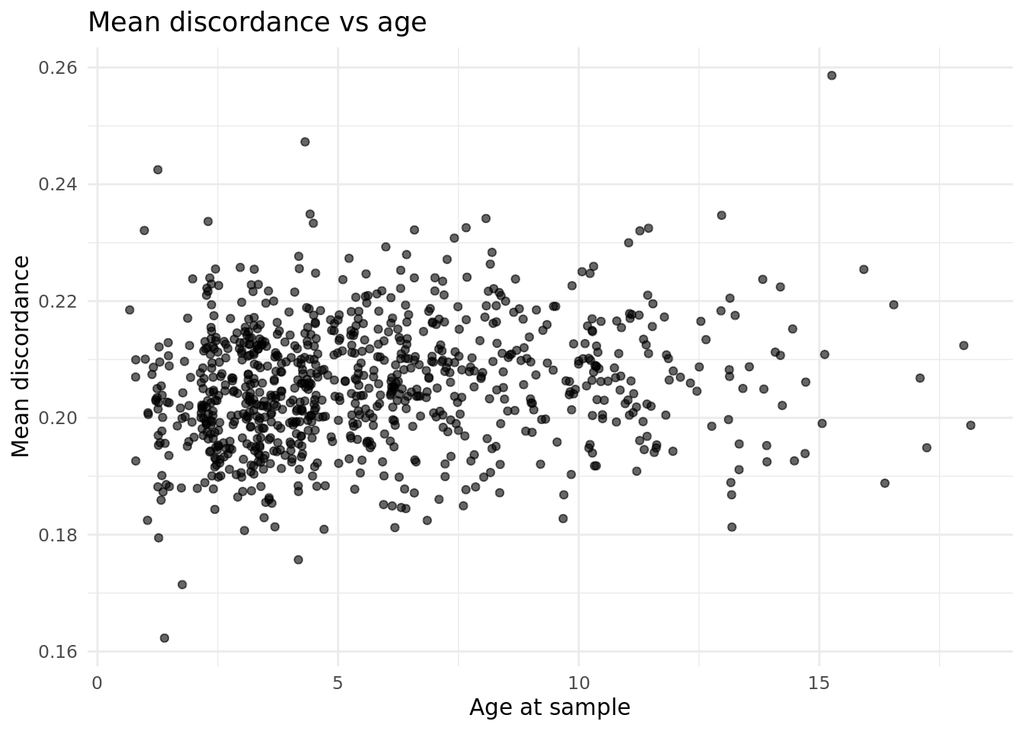

```r
ggplot(analysis_df, aes(x = Age_at_sample, y = mean_dis)) +
  geom_point(alpha = 0.6) +
  theme_minimal() +
  labs(x = "Age at sample", y = "Mean discordance", title = "Mean discordance vs age")
```

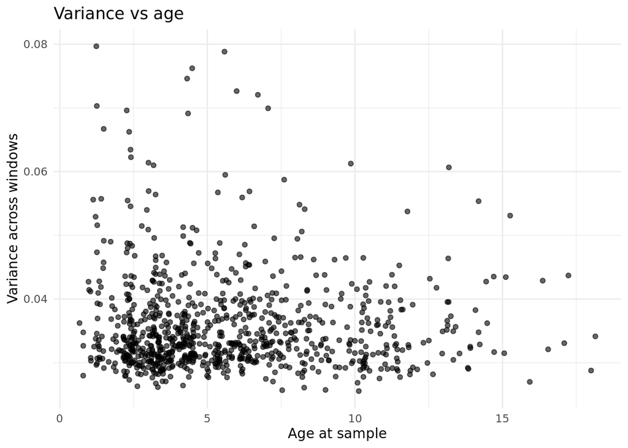

```r
ggplot(analysis_df, aes(x = Age_at_sample, y = var_dis)) +
  geom_point(alpha = 0.6) +
  theme_minimal() +
  labs(x = "Age at sample", y = "Variance across windows", title = "Variance vs age")
```

```r
p <- ggplot(
  analysis_df,
  aes(
    x = Age_at_sample,
    y = mean_dis,
    color = Breed_Size_Class_at_HLES,
    text = paste(
      "Dog ID:", dog_id,
      "<br>Age:", Age_at_sample,
      "<br>Mean discordance:", round(mean_dis, 3),
      "<br>Breed size:", Breed_Size_Class_at_HLES
    )
  )
) +
  geom_point(alpha = 0.6) +
  geom_smooth(method = "lm", se = FALSE, linewidth = 1.2) +
  theme_minimal() +
  labs(
    color = "Breed size",
    title = "Age–discordance trajectories by body size",
    x = "Age at sample",
    y = "Mean discordance"
  )

ggplotly(p, tooltip = "text") %>%
  style(visible = "legendonly")
```

[interactive chart not shown]

this mean discoradnce plot is in the range of 0.18 - 0.24; this saying that the data is having consistency showing almost the same result through out the age at sample of each dogs; which was proven on the second plot; showing that the majority of variance between each windows for each dogs is mainly around 0.04; there are still variance window that are higher than 0.05; but it still not significant as 0.04 and lower.

```r
summary(analysis_df$n_win)
```

```
##    Min. 1st Qu.  Median    Mean 3rd Qu.    Max.
##   82982  143837  147642  145264  149299  152745
```

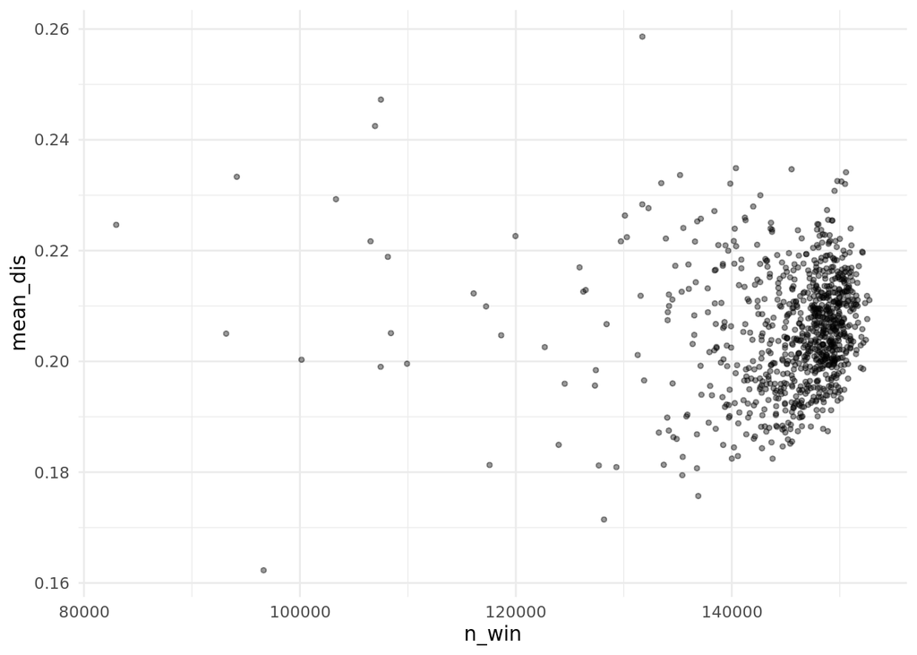

```r
ggplot(analysis_df, aes(n_win, mean_dis)) +
  geom_point(alpha = 0.4, size = 1) +
  theme_minimal()
```

```r
l<- ggplot(analysis_df, aes(x = Age_at_sample, y = mean_dis, color = Sex,
                        text = paste(
      "Dog ID:", dog_id,
      "<br>Age:", Age_at_sample,
      "<br>Mean discordance:", round(mean_dis, 3),
      "<br>Gender:", Sex))) +
  geom_point(alpha = 0.6) +
  geom_smooth(method = "lm", se = FALSE) +
  theme_minimal()

m<- ggplot(analysis_df, aes(x = Age_at_sample, y = mean_dis, color = fixed,
                        text = paste(
      "Dog ID:", dog_id,
      "<br>Age:", Age_at_sample,
      "<br>Mean discordance:", round(mean_dis, 3),
      "<br>Fixedness:", fixed))) +
  geom_point(alpha = 0.6) +
  geom_smooth(method = "lm", se = FALSE) +
  theme_minimal()

ggplotly(l, tooltip = "text") %>%
  style(visible = "legendonly")
```

[interactive chart not shown]

```r
ggplotly(m, tooltip = "text") %>%
  style(visible = "legendonly")
```

[interactive chart not shown]

## CASE 5: Coverage or technical effect dominates

the trend showing that at high number of window, the mean discoradnce tend to clustered between 0.18-0.24 (just like other plot showing, which is nice that the data is reproduce itself); and extreme value showing at lower number of sample;

this step will show first analyze the coverage and how it affect the mean discordance first

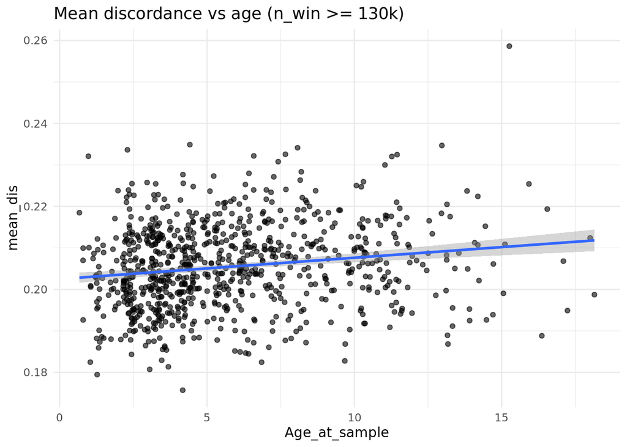

```r
df_130k <- analysis_df %>% filter(n_win >= 130000)
df_135k <- analysis_df %>% filter(n_win >= 135000)

ggplot(df_130k, aes(Age_at_sample, mean_dis)) +
  geom_point(alpha = 0.6) +
  geom_smooth(method = "lm", se = TRUE) +
  theme_minimal() +
  labs(title = "Mean discordance vs age (n_win >= 130k)")
```

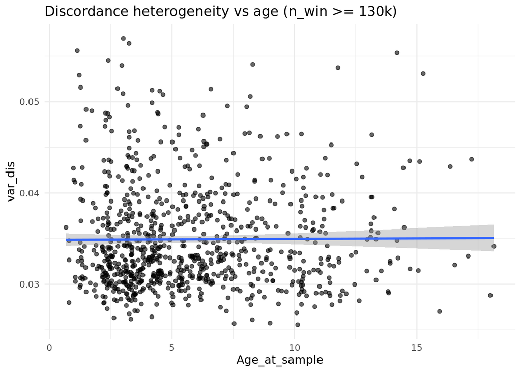

```r
ggplot(df_130k, aes(Age_at_sample, var_dis)) +
  geom_point(alpha = 0.6) +
  geom_smooth(method = "lm", se = TRUE) +
  theme_minimal() +
  labs(title = "Discordance heterogeneity vs age (n_win >= 130k)")
```

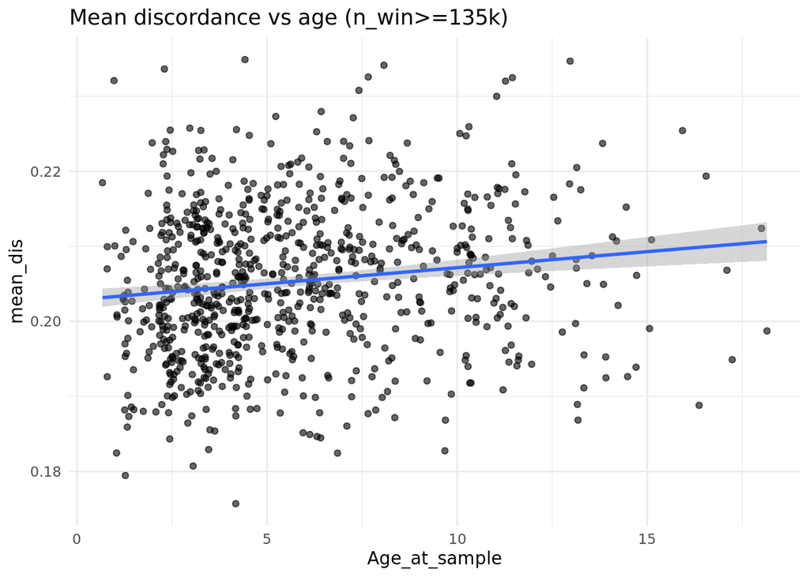

```r
ggplot(df_135k, aes(Age_at_sample, mean_dis)) +
  geom_point(alpha = 0.6) +
  geom_smooth(method = "lm", se = TRUE) +
  theme_minimal() +
  labs(title = "Mean discordance vs age (n_win>=135k)")
```

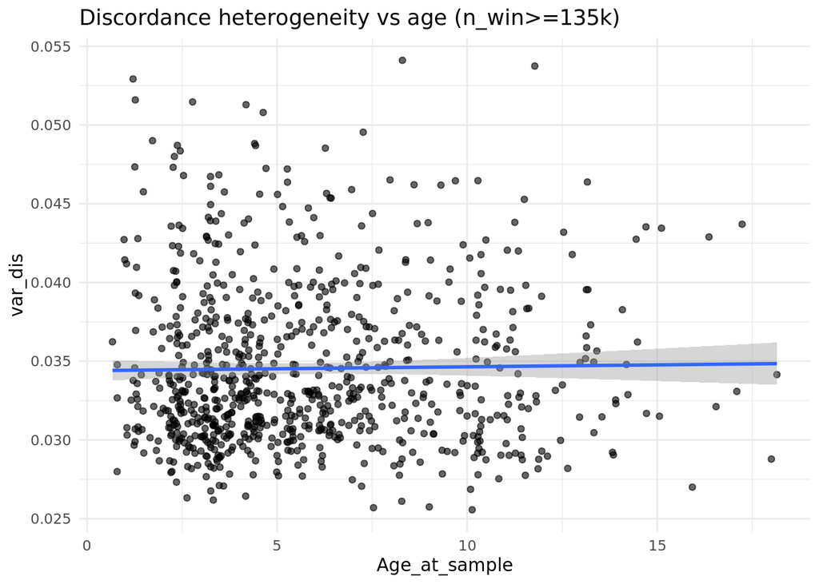

```r
ggplot(df_135k, aes(Age_at_sample, var_dis)) +
  geom_point(alpha = 0.6) +
  geom_smooth(method = "lm", se = TRUE) +
  theme_minimal() +
  labs(title = "Discordance heterogeneity vs age (n_win>=135k)")
```

since variance discordance is more stable; then it will be the next step of analyzing

```r
p1 <- ggplot(df_130k, aes(Age_at_sample, var_dis, color = Breed_Size_Class_at_HLES)) +
  geom_point(alpha = 0.5, size = 1)+
  geom_smooth(method = "lm", se = TRUE) +
  theme_minimal()

p2 <- ggplot(df_130k, aes(Age_at_sample, var_dis, color = Sex)) +
  geom_point(alpha = 0.5, size = 1)+
  geom_smooth(method = "lm", se = TRUE) +
  theme_minimal()
p2a <- ggplot(analysis_df, aes(Age_at_sample, var_dis, color = Sex)) +
  geom_point(alpha = 0.5, size = 1)+
  geom_smooth(method = "lm", se = TRUE) +
  theme_minimal()
ggplotly(p1, tooltip = "text")
```

[interactive chart not shown]

```r
ggplotly(p2, tooltip = "text")
```

[interactive chart not shown]

```r
ggplotly(p2a, tooltip = "text")
```

[interactive chart not shown]

after filter the n_win >= 130k; sex-stratified analyses revelaed divergent age-associated trends in variance of methylation discordance. Female dogs exhibited a modest increase in varaince with age, whereas males showed a slught decrease, suggesting sex-specific patterns of epigenetic heterogeneity

```r
m_var <- lm(var_dis ~ Age_at_sample * Sex, data = df_130k)
summary(m_var)
```

```
##
## Call:
## lm(formula = var_dis ~ Age_at_sample * Sex, data = df_130k)
##
## Residuals:
##       Min        1Q    Median        3Q       Max
## -0.010025 -0.004084 -0.001466  0.002724  0.021719
##
## Coefficients:
##                         Estimate Std. Error t value Pr(>|t|)
## (Intercept)            3.419e-02  5.445e-04  62.783   <2e-16 ***
## Age_at_sample          1.383e-04  8.028e-05   1.722   0.0854 .
## SexMale                1.435e-03  7.738e-04   1.855   0.0640 .
## Age_at_sample:SexMale -2.682e-04  1.163e-04  -2.307   0.0213 *
## ---
## Signif. codes:  0 '***' 0.001 '**' 0.01 '*' 0.05 '.' 0.1 ' ' 1
##
## Residual standard error: 0.005629 on 842 degrees of freedom
## Multiple R-squared:  0.006416,   Adjusted R-squared:  0.002876
## F-statistic: 1.812 on 3 and 842 DF,  p-value: 0.1433
```

```r
m_var_135 <- lm(var_dis ~ Age_at_sample * Sex, data = df_135k)
summary(m_var_135)
```

```
##
## Call:
## lm(formula = var_dis ~ Age_at_sample * Sex, data = df_135k)
##
## Residuals:
##       Min        1Q    Median        3Q       Max
## -0.009425 -0.003743 -0.001380  0.002787  0.019716
##
## Coefficients:
##                         Estimate Std. Error t value Pr(>|t|)
## (Intercept)            3.390e-02  5.016e-04  67.592   <2e-16 ***
## Age_at_sample          1.074e-04  7.425e-05   1.446    0.148
## SexMale                1.014e-03  7.107e-04   1.427    0.154
## Age_at_sample:SexMale -1.706e-04  1.066e-04  -1.600    0.110
## ---
## Signif. codes:  0 '***' 0.001 '**' 0.01 '*' 0.05 '.' 0.1 ' ' 1
##
## Residual standard error: 0.005084 on 819 degrees of freedom
## Multiple R-squared:  0.003383,   Adjusted R-squared:  -0.0002671
## F-statistic: 0.9268 on 3 and 819 DF,  p-value: 0.4272
```

```r
m_mean <- lm(mean_dis ~ Age_at_sample * Sex, data = df_135k)
summary(m_mean)
```

```
##
## Call:
## lm(formula = mean_dis ~ Age_at_sample * Sex, data = df_135k)
##
## Residuals:
##        Min         1Q     Median         3Q        Max
## -0.0283857 -0.0064270 -0.0002494  0.0069020  0.0307228
##
## Coefficients:
##                         Estimate Std. Error t value Pr(>|t|)
## (Intercept)            0.2031065  0.0009575 212.130  < 2e-16 ***
## Age_at_sample          0.0005262  0.0001417   3.712 0.000219 ***
## SexMale               -0.0003443  0.0013568  -0.254 0.799729
## Age_at_sample:SexMale -0.0002088  0.0002036  -1.026 0.305225
## ---
## Signif. codes:  0 '***' 0.001 '**' 0.01 '*' 0.05 '.' 0.1 ' ' 1
##
## Residual standard error: 0.009705 on 819 degrees of freedom
## Multiple R-squared:  0.02842,    Adjusted R-squared:  0.02486
## F-statistic: 7.985 on 3 and 819 DF,  p-value: 2.992e-05
```

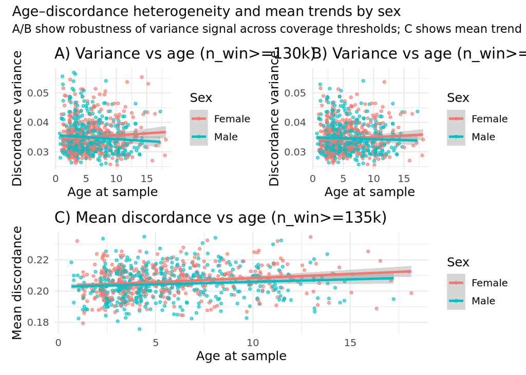

```r
# 1) Shared axis limits (so panels are comparable)
x_lim <- range(analysis_df$Age_at_sample, na.rm = TRUE)

y_var_lim <- range(
  c(df_130k$var_dis, df_135k$var_dis),
  na.rm = TRUE
)

y_mean_lim <- range(df_135k$mean_dis, na.rm = TRUE)

# 2) Panel A: var_dis vs age (n_win >= 130k), colored by sex
pA <- ggplot(df_130k, aes(x = Age_at_sample, y = var_dis, color = Sex)) +
  geom_point(alpha = 0.6, size = 1) +
  geom_smooth(method = "lm", se = TRUE) +
  coord_cartesian(xlim = x_lim, ylim = y_var_lim) +
  theme_minimal(base_size = 12) +
  labs(
    title = "A) Variance vs age (n_win>=130k)",
    x = "Age at sample",
    y = "Discordance variance",
    color = "Sex"
  )

# 3) Panel B: var_dis vs age (n_win >= 135k), colored by sex (robustness subset)
pB <- ggplot(df_135k, aes(x = Age_at_sample, y = var_dis, color = Sex)) +
  geom_point(alpha = 0.6, size = 1) +
  geom_smooth(method = "lm", se = TRUE) +
  coord_cartesian(xlim = x_lim, ylim = y_var_lim) +
  theme_minimal(base_size = 12) +
  labs(
    title = "B) Variance vs age (n_win>=135k)",
    x = "Age at sample",
    y = "Discordance variance",
    color = "Sex"
  )

# 4) Panel C: mean_dis vs age (high coverage only, because mean is coverage-sensitive)
pC <- ggplot(df_135k, aes(x = Age_at_sample, y = mean_dis, color = Sex)) +
  geom_point(alpha = 0.6, size = 1) +
  geom_smooth(method = "lm", se = TRUE) +
  coord_cartesian(xlim = x_lim, ylim = y_mean_lim) +
  theme_minimal(base_size = 12) +
  labs(
    title = "C) Mean discordance vs age (n_win>=135k)",
    x = "Age at sample",
    y = "Mean discordance",
    color = "Sex"
  )

# 5) Combine into a single figure
fig_11 <- (pA | pB) / pC +
  plot_annotation(
    title = "Age–discordance heterogeneity and mean trends by sex",
    subtitle = "A/B show robustness of variance signal across coverage thresholds; C shows mean trend in the highest-coverage subset"
  )

# 6) Print in RStudio / notebook
fig_11
```

from this 3 panel plot; we can say that male age_variance relationship is weak and sensitive to inclusion criteria; to conclude this 2 data prep prep 1

```r
male_130k <- df_130k %>% filter(Sex == "Male")
male_135k <- df_135k %>% filter(Sex == "Male")
m_male_130k <- lm(var_dis ~ Age_at_sample, data = male_130k)
m_male_135k <- lm(var_dis ~ Age_at_sample, data = male_135k)

summary(m_male_130k)
```

```
##
## Call:
## lm(formula = var_dis ~ Age_at_sample, data = male_130k)
##
## Residuals:
##       Min        1Q    Median        3Q       Max
## -0.008963 -0.004060 -0.001526  0.002600  0.021719
##
## Coefficients:
##                 Estimate Std. Error t value Pr(>|t|)
## (Intercept)    3.562e-02  5.387e-04  66.124   <2e-16 ***
## Age_at_sample -1.300e-04  8.243e-05  -1.577    0.116
## ---
## Signif. codes:  0 '***' 0.001 '**' 0.01 '*' 0.05 '.' 0.1 ' ' 1
##
## Residual standard error: 0.005516 on 435 degrees of freedom
## Multiple R-squared:  0.005683,   Adjusted R-squared:  0.003398
## F-statistic: 2.486 on 1 and 435 DF,  p-value: 0.1156
```

```r
summary(m_male_135k)
```

```
##
## Call:
## lm(formula = var_dis ~ Age_at_sample, data = male_135k)
##
## Residuals:
##       Min        1Q    Median        3Q       Max
## -0.008743 -0.003736 -0.001460  0.002684  0.019716
##
## Coefficients:
##                 Estimate Std. Error t value Pr(>|t|)
## (Intercept)    3.492e-02  4.965e-04  70.325   <2e-16 ***
## Age_at_sample -6.324e-05  7.546e-05  -0.838    0.403
## ---
## Signif. codes:  0 '***' 0.001 '**' 0.01 '*' 0.05 '.' 0.1 ' ' 1
##
## Residual standard error: 0.005013 on 425 degrees of freedom
## Multiple R-squared:  0.001649,   Adjusted R-squared:  -0.0006996
## F-statistic: 0.7022 on 1 and 425 DF,  p-value: 0.4025
```

```r
bind_rows(
  tidy(m_male_130k) %>% mutate(dataset = "Male, n_win>=130k"),
  tidy(m_male_135k) %>% mutate(dataset = "Male, n_win>=135k")
) %>%
  filter(term == "Age_at_sample")
```

```
## # A tibble: 2 × 6
##   term            estimate std.error statistic p.value dataset
##   <chr>              <dbl>     <dbl>     <dbl>   <dbl> <chr>
## 1 Age_at_sample -0.000130  0.0000824    -1.58    0.116 Male, n_win>=130k
## 2 Age_at_sample -0.0000632 0.0000755    -0.838   0.403 Male, n_win>=135k
```

STEP B

```r
male_combined <- bind_rows(
  male_130k %>% mutate(threshold = "130k"),
  male_135k %>% mutate(threshold = "135k")
)
m_interact <- lm(
  var_dis ~ Age_at_sample * threshold,
  data = male_combined
)

summary(m_interact)
```

```
##
## Call:
## lm(formula = var_dis ~ Age_at_sample * threshold, data = male_combined)
##
## Residuals:
##       Min        1Q    Median        3Q       Max
## -0.008963 -0.003864 -0.001473  0.002652  0.021719
##
## Coefficients:
##                               Estimate Std. Error t value Pr(>|t|)
## (Intercept)                  3.562e-02  5.150e-04  69.170   <2e-16 ***
## Age_at_sample               -1.300e-04  7.880e-05  -1.649   0.0994 .
## threshold135k               -7.083e-04  7.335e-04  -0.966   0.3345
## Age_at_sample:threshold135k  6.674e-05  1.119e-04   0.597   0.5509
## ---
## Signif. codes:  0 '***' 0.001 '**' 0.01 '*' 0.05 '.' 0.1 ' ' 1
##
## Residual standard error: 0.005273 on 860 degrees of freedom
## Multiple R-squared:  0.004865,   Adjusted R-squared:  0.001394
## F-statistic: 1.402 on 3 and 860 DF,  p-value: 0.241
```

```r
summary(lm(mean_dis ~ Age_at_sample, data = df_130k))
```

```
##
## Call:
## lm(formula = mean_dis ~ Age_at_sample, data = df_130k)
##
## Residuals:
##       Min        1Q    Median        3Q       Max
## -0.028929 -0.006653 -0.000327  0.007057  0.048299
##
## Coefficients:
##                Estimate Std. Error t value Pr(>|t|)
## (Intercept)   0.2024869  0.0006899 293.519  < 2e-16 ***
## Age_at_sample 0.0005135  0.0001036   4.955 8.75e-07 ***
## ---
## Signif. codes:  0 '***' 0.001 '**' 0.01 '*' 0.05 '.' 0.1 ' ' 1
##
## Residual standard error: 0.01005 on 844 degrees of freedom
## Multiple R-squared:  0.02827,    Adjusted R-squared:  0.02711
## F-statistic: 24.55 on 1 and 844 DF,  p-value: 8.75e-07
```

```r
summary(lm(mean_dis ~ Age_at_sample, data = df_135k))
```

```
##
## Call:
## lm(formula = mean_dis ~ Age_at_sample, data = df_135k)
##
## Residuals:
##        Min         1Q     Median         3Q        Max
## -0.0289592 -0.0065103 -0.0002505  0.0067427  0.0301225
##
## Coefficients:
##                Estimate Std. Error t value Pr(>|t|)
## (Intercept)   0.2028759  0.0006797 298.466  < 2e-16 ***
## Age_at_sample 0.0004275  0.0001020   4.191 3.08e-05 ***
## ---
## Signif. codes:  0 '***' 0.001 '**' 0.01 '*' 0.05 '.' 0.1 ' ' 1
##
## Residual standard error: 0.009731 on 821 degrees of freedom
## Multiple R-squared:  0.02095,    Adjusted R-squared:  0.01976
## F-statistic: 17.57 on 1 and 821 DF,  p-value: 3.076e-05
```

```r
summary(lm(var_dis ~ Age_at_sample * Sex, data = df_135k))
```

```
##
## Call:
## lm(formula = var_dis ~ Age_at_sample * Sex, data = df_135k)
##
## Residuals:
##       Min        1Q    Median        3Q       Max
## -0.009425 -0.003743 -0.001380  0.002787  0.019716
##
## Coefficients:
##                         Estimate Std. Error t value Pr(>|t|)
## (Intercept)            3.390e-02  5.016e-04  67.592   <2e-16 ***
## Age_at_sample          1.074e-04  7.425e-05   1.446    0.148
## SexMale                1.014e-03  7.107e-04   1.427    0.154
## Age_at_sample:SexMale -1.706e-04  1.066e-04  -1.600    0.110
## ---
## Signif. codes:  0 '***' 0.001 '**' 0.01 '*' 0.05 '.' 0.1 ' ' 1
##
## Residual standard error: 0.005084 on 819 degrees of freedom
## Multiple R-squared:  0.003383,   Adjusted R-squared:  -0.0002671
## F-statistic: 0.9268 on 3 and 819 DF,  p-value: 0.4272
```

###Genomics analysis

```r
# --- keep rownames for genomics ---
rownames(D) <- rownames(D_ori)

# Dogs you want in the scan
df_use <- analysis_df %>% filter(n_win >= 130000)

# Map dog_id -> lid_pid columns (the sample-level columns in D_ori)
col_map <- meta %>%
  select(lid_pid, dog_id) %>%
  distinct() %>%
  filter(dog_id %in% df_use$dog_id) %>%
  filter(lid_pid %in% colnames(D))   # use D, since you're indexing D

# Collapse sample columns to dog columns (mean across that dog's lid_pid columns)
cols_by_dog <- split(col_map$lid_pid, col_map$dog_id)

D_use <- sapply(names(cols_by_dog), function(dog) {
  cols <- cols_by_dog[[dog]]
  rowMeans(D[, cols, drop = FALSE], na.rm = TRUE)
})
D_use <- as.matrix(D_use)  # windows x dogs

# Align df_use order to D_use columns
df_use <- df_use %>%
  filter(dog_id %in% colnames(D_use)) %>%
  mutate(dog_id = factor(dog_id, levels = colnames(D_use))) %>%
  arrange(dog_id)

age <- df_use$Age_at_sample
stopifnot(length(age) == ncol(D_use))

# ---- window filters ----
min_prop_obs <- 0.80
min_n_obs <- ceiling(min_prop_obs * ncol(D_use))

n_obs <- rowSums(!is.na(D_use))
var_win <- apply(D_use, 1, var, na.rm = TRUE)

keep_win <- (n_obs >= min_n_obs) & is.finite(var_win) & (var_win > 0)
table(keep_win)
```

```
## keep_win
##  FALSE   TRUE
##  40455 143697
```

```r
# Apply filter
D_scan <- D_use[keep_win, , drop = FALSE]

# Recompute aligned stats FROM D_scan (important!)
n_obs_scan <- rowSums(!is.na(D_scan))
var_win_scan <- apply(D_scan, 1, var, na.rm = TRUE)

# Rebuild win_tbl_scan from D_scan rownames (guaranteed alignment)
win_tbl_scan <- tibble(window_id = rownames(D_scan)) %>%
  extract(
    window_id,
    into = c("chr", "start", "end"),
    regex = "^chr([0-9XY]+)_([0-9]+)_([0-9]+)$",
    remove = FALSE
  ) %>%
  mutate(
    chr = paste0("chr", chr),
    start = as.integer(start),
    end = as.integer(end)
  )

# ---- correlation with age ----
r_age <- apply(D_scan, 1, function(x)
  suppressWarnings(cor(x, age, use = "pairwise.complete.obs"))
)

# convert to p-values (MUST use n_obs_scan)
df_cor <- n_obs_scan - 2
t_stat <- r_age * sqrt(df_cor / pmax(1 - r_age^2, 1e-12))
p_age <- 2 * pt(abs(t_stat), df = df_cor, lower.tail = FALSE)

# FDR
fdr_age <- p.adjust(p_age, method = "BH")

# Assemble results (all vectors now same length)
scan_age <- win_tbl_scan %>%
  mutate(
    n_obs = n_obs_scan,
    var_win = var_win_scan,
    r_age = r_age,
    p_age = p_age,
    fdr_age = fdr_age
  ) %>%
  arrange(fdr_age)

# Safety check
stopifnot(nrow(scan_age) == length(p_age))
```

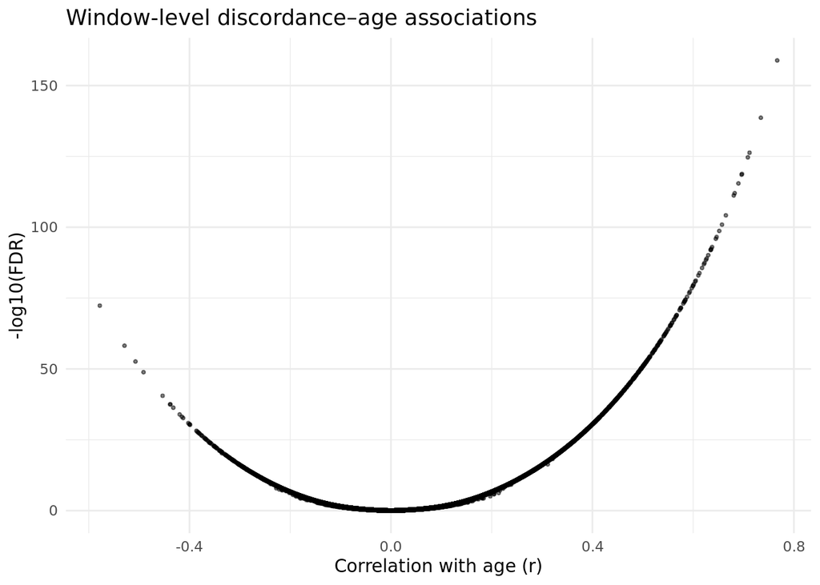

```r
ggplot(scan_age, aes(x = r_age, y = -log10(fdr_age))) +
  geom_point(alpha = 0.5, size = 0.7) +
  theme_minimal() +
  labs(
    x = "Correlation with age (r)",
    y = "-log10(FDR)",
    title = "Window-level discordance–age associations"
  )
```

```r
scan_age2 <- scan_age %>%
  mutate(chr_num = as.integer(gsub("chr", "", chr))) %>%
  arrange(chr_num, start) %>%
  mutate(genome_idx = row_number())
```

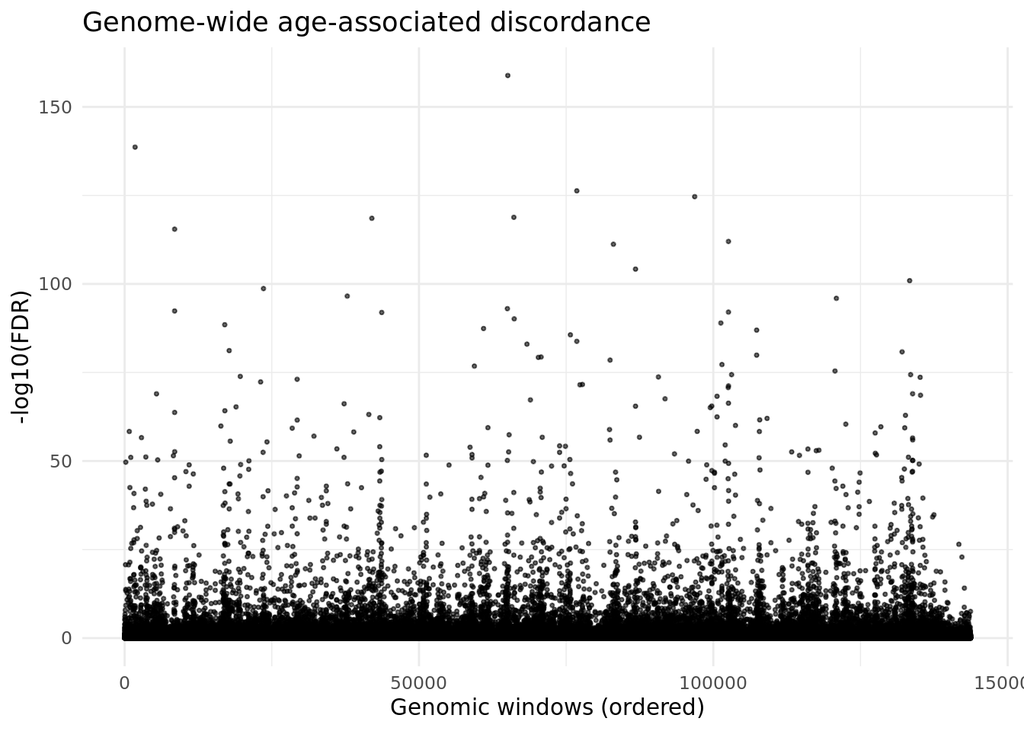

```r
ggplot(scan_age2, aes(x = genome_idx, y = -log10(fdr_age))) +
  geom_point(alpha = 0.6, size = 0.6) +
  theme_minimal() +
  labs(
    x = "Genomic windows (ordered)",
    y = "-log10(FDR)",
    title = "Genome-wide age-associated discordance"
  )
```

```r
hits_age <- scan_age %>% filter(fdr_age < 0.05)
nrow(hits_age)
```

```
## [1] 19976
```

```r
table(sign = ifelse(hits_age$r_age > 0, "Increase with age", "Decrease with age"))
```

```
## sign
## Decrease with age Increase with age
##              5258             14718
```

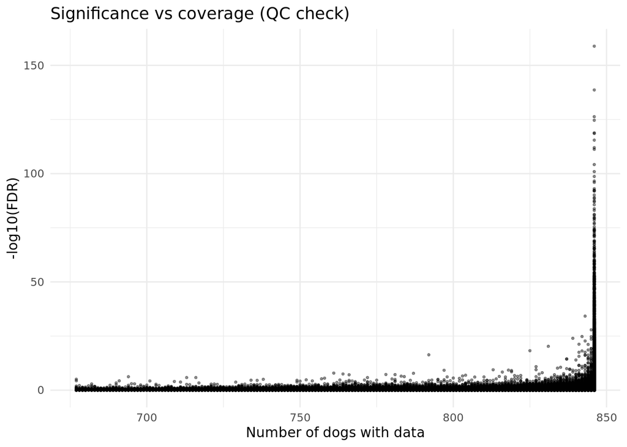

```r
ggplot(scan_age, aes(x = n_obs, y = -log10(fdr_age))) +
  geom_point(alpha = 0.4, size = 0.6) +
  theme_minimal() +
  labs(
    x = "Number of dogs with data",
    y = "-log10(FDR)",
    title = "Significance vs coverage (QC check)"
  )
```

```r
scan_age <- scan_age %>% filter(n_obs >= 0.8 * ncol(D_use))
```

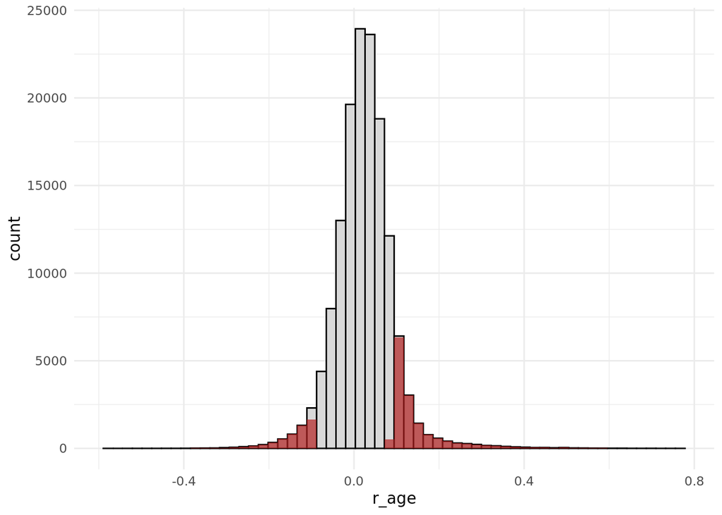

```r
ggplot(scan_age, aes(x = r_age)) +
  geom_histogram(bins = 60, fill = "grey85", color = "black") +
  geom_histogram(
    data = hits_age,
    aes(x = r_age),
    bins = 60,
    fill = "firebrick",
    alpha = 0.7
  ) +
  theme_minimal()
```

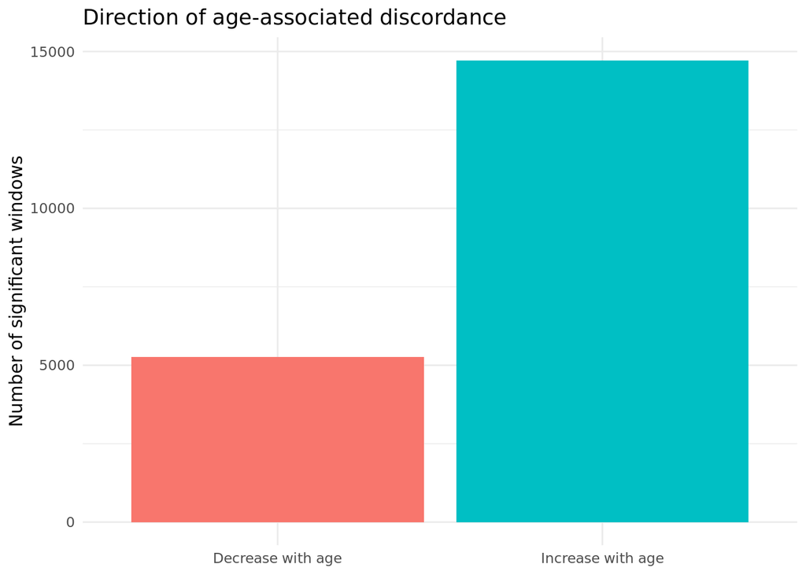

```r
hits_age %>%
  mutate(direction = ifelse(r_age > 0, "Increase with age", "Decrease with age")) %>%
  count(direction) %>%
  ggplot(aes(x = direction, y = n, fill = direction)) +
  geom_col() +
  theme_minimal() +
  labs(
    x = NULL,
    y = "Number of significant windows",
    title = "Direction of age-associated discordance"
  ) +
  theme(legend.position = "none")
```

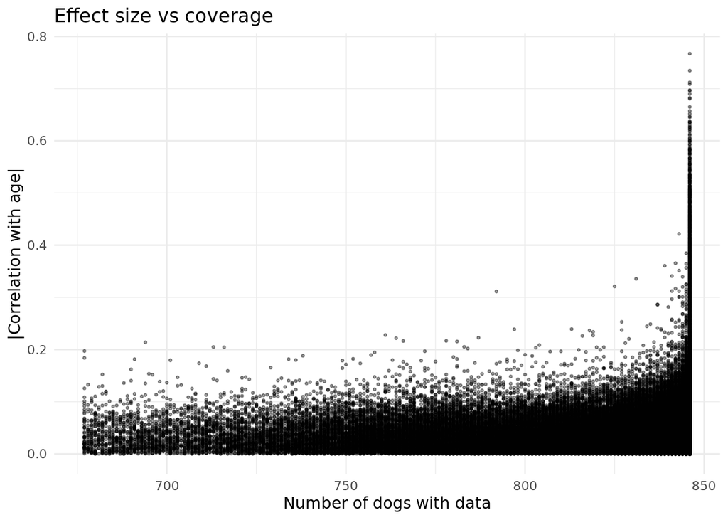

```r
ggplot(scan_age, aes(x = n_obs, y = abs(r_age))) +
  geom_point(alpha = 0.4, size = 0.6) +
  theme_minimal() +
  labs(
    x = "Number of dogs with data",
    y = "|Correlation with age|",
    title = "Effect size vs coverage"
  )
```

###G7A

```r
scan_with_age <- function(Dmat, age_vec, min_prop_obs = 0.8) {

  min_n_obs <- ceiling(min_prop_obs * ncol(Dmat))
  n_obs <- rowSums(!is.na(Dmat))
  var_win <- apply(Dmat, 1, var, na.rm = TRUE)

  keep <- (n_obs >= min_n_obs) & is.finite(var_win) & (var_win > 0)

  Df <- Dmat[keep, , drop = FALSE]
  n_obs_f <- rowSums(!is.na(Df))

  r <- apply(Df, 1, function(x)
    suppressWarnings(cor(x, age_vec, use = "pairwise.complete.obs"))
  )

  df_cor <- n_obs_f - 2
  t_stat <- r * sqrt(df_cor / pmax(1 - r^2, 1e-12))
  p <- 2 * pt(abs(t_stat), df = df_cor, lower.tail = FALSE)
  fdr <- p.adjust(p, method = "BH")

  tibble(
    window_id = rownames(Df),
    n_obs = n_obs_f,
    r_age = r,
    p_age = p,
    fdr_age = fdr
  )
}
```

A1

```r
df_male   <- df_use %>% filter(Sex == "Male")
df_female <- df_use %>% filter(Sex == "Female")

D_male   <- D_use[, df_male$dog_id, drop = FALSE]
D_female <- D_use[, df_female$dog_id, drop = FALSE]
```

A2

```r
scan_male <- scan_with_age(D_male, df_male$Age_at_sample, min_prop_obs = 0.80)
scan_female <- scan_with_age(D_female, df_female$Age_at_sample, min_prop_obs = 0.80)

# Add sex label (helpful for combined summaries)
scan_male <- scan_male %>% mutate(sex = "Male")
scan_female <- scan_female %>% mutate(sex = "Female")
```

A3

```r
add_coords <- function(df) {
  df %>%
    extract(
      window_id,
      into = c("chr", "start", "end"),
      regex = "^chr_(\\d+)_([0-9]+)_([0-9]+)$",
      remove = FALSE
    ) %>%
    mutate(
      chr = paste0("chr", chr),
      start = as.integer(start),
      end = as.integer(end)
    )
}

scan_male <- add_coords(scan_male)
scan_female <- add_coords(scan_female)
```

A4

```r
FDR_CUTOFF <- 0.05

hits_male <- scan_male %>% filter(fdr_age < FDR_CUTOFF)
hits_female <- scan_female %>% filter(fdr_age < FDR_CUTOFF)

n_male <- nrow(hits_male)
n_female <- nrow(hits_female)

overlap_ids <- intersect(hits_male$window_id, hits_female$window_id)

c(
  hits_male = n_male,
  hits_female = n_female,
  overlap = length(overlap_ids),
  male_only = length(setdiff(hits_male$window_id, hits_female$window_id)),
  female_only = length(setdiff(hits_female$window_id, hits_male$window_id))
)
```

```
##   hits_male hits_female     overlap   male_only female_only
##        7554       12076        4463        3091        7613
```

A5

```r
dir_summary <- function(hits_df) {
  hits_df %>%
    mutate(direction = ifelse(r_age > 0, "Increase with age", "Decrease with age")) %>%
    count(direction)
}

dir_summary(hits_male)
```

```
## # A tibble: 2 × 2
##   direction             n
##   <chr>             <int>
## 1 Decrease with age  2430
## 2 Increase with age  5124
```

```r
dir_summary(hits_female)
```

```
## # A tibble: 2 × 2
##   direction             n
##   <chr>             <int>
## 1 Decrease with age  2536
## 2 Increase with age  9540
```

A6

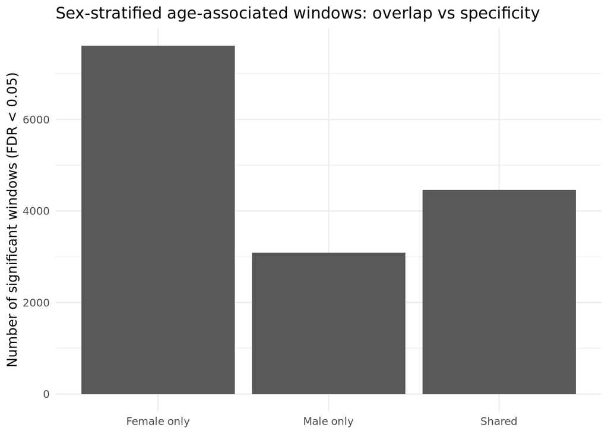

```r
overlap_tbl <- tibble(
  group = c("Male only", "Shared", "Female only"),
  n = c(
    length(setdiff(hits_male$window_id, hits_female$window_id)),
    length(overlap_ids),
    length(setdiff(hits_female$window_id, hits_male$window_id))
  )
)

ggplot(overlap_tbl, aes(x = group, y = n)) +
  geom_col() +
  theme_minimal() +
  labs(
    x = NULL,
    y = "Number of significant windows (FDR < 0.05)",
    title = "Sex-stratified age-associated windows: overlap vs specificity"
  )
```

###G7B

B1

```r
FDR_CUTOFF <- 0.05

scan_age_ord <- scan_age %>%
  mutate(chr_num = as.integer(gsub("^chr", "", chr))) %>%
  arrange(chr_num, start) %>%
  mutate(genome_idx = row_number())
hits_ord <- scan_age_ord %>% filter(fdr_age < FDR_CUTOFF)

nrow(hits_ord)
```

```
## [1] 19976
```

B2

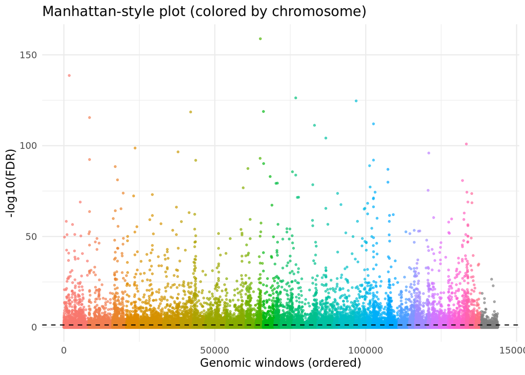

```r
ggplot(scan_age_ord, aes(x = genome_idx, y = -log10(fdr_age), color = factor(chr_num))) +
  geom_point(alpha = 0.6, size = 0.6) +
  geom_hline(yintercept = -log10(FDR_CUTOFF), linetype = "dashed") +
  theme_minimal() +
  guides(color = "none") +
  labs(
    x = "Genomic windows (ordered)",
    y = "-log10(FDR)",
    title = "Manhattan-style plot (colored by chromosome)"
  )
```

B3

```r
hits_spacing <- hits_ord %>%
  group_by(chr) %>%
  arrange(start) %>%
  mutate(dist_to_prev = start - lag(start)) %>%
  ungroup()

summary(hits_spacing$dist_to_prev)
```

```
##    Min. 1st Qu.  Median    Mean 3rd Qu.    Max.    NA's
##     288    4148   20589  117145   94412 4569422      39
```

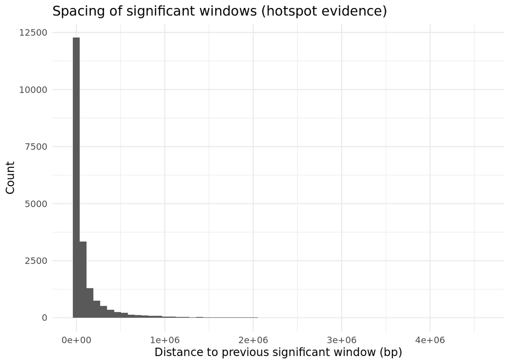

```r
ggplot(hits_spacing, aes(x = dist_to_prev)) +
  geom_histogram(bins = 60) +
  theme_minimal() +
  labs(
    x = "Distance to previous significant window (bp)",
    y = "Count",
    title = "Spacing of significant windows (hotspot evidence)"
  )
```

B4

```r
set.seed(1)

# observed distances (drop NA from first in each chr)
real_dist <- hits_spacing$dist_to_prev
real_dist <- real_dist[!is.na(real_dist)]

# random: sample the same number of windows as hits, compute spacing
rand_dist <- scan_age_ord %>%
  sample_n(nrow(hits_ord)) %>%
  group_by(chr) %>%
  arrange(start) %>%
  mutate(dist_to_prev = start - lag(start)) %>%
  ungroup() %>%
  pull(dist_to_prev)

rand_dist <- rand_dist[!is.na(rand_dist)]

# test whether real distances are smaller (more clustered)
t.test(real_dist, rand_dist, alternative = "less")
```

```
##
##  Welch Two Sample t-test
##
## data:  real_dist and rand_dist
## t = -0.19086, df = 39547, p-value = 0.4243
## alternative hypothesis: true difference in means is less than 0
## 95 percent confidence interval:
##      -Inf 3910.731
## sample estimates:
## mean of x mean of y
##  117144.7  117658.0
```

B5

```r
# Summarize clustering test results
clustering_summary <- tibble(
  metric = c("Mean distance (observed)", "Mean distance (random)", "p_value"),
  value = c(
    mean(real_dist, na.rm = TRUE),
    mean(rand_dist, na.rm = TRUE),
    0.4243
  )
)

clustering_summary
```

```
## # A tibble: 3 × 2
##   metric                        value
##   <chr>                         <dbl>
## 1 Mean distance (observed) 117145.
## 2 Mean distance (random)   117658.
## 3 p_value                       0.424
```

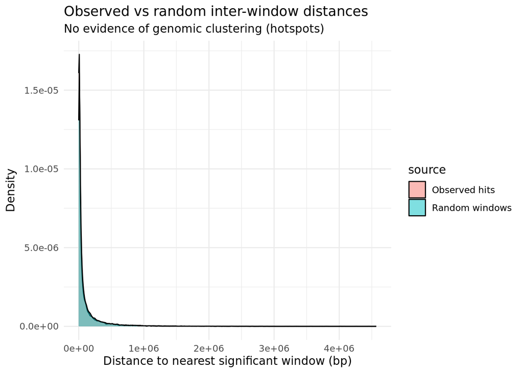

```r
dist_df <- tibble(
  distance = c(real_dist, rand_dist),
  source = rep(c("Observed hits", "Random windows"),
               times = c(length(real_dist), length(rand_dist)))
)

ggplot(dist_df, aes(x = distance, fill = source)) +
  geom_density(alpha = 0.5) +
  theme_minimal() +
  labs(
    x = "Distance to nearest significant window (bp)",
    y = "Density",
    title = "Observed vs random inter-window distances",
    subtitle = "No evidence of genomic clustering (hotspots)"
  )
```